# 140.651 - Lab 5

### HW2 Problem 12

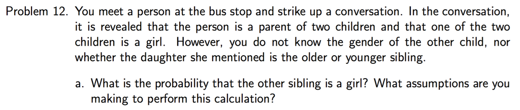

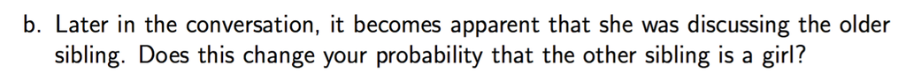

#### (a) What is the probability that the other sibling is a girl? What assumptions are you making to perform this calculation?

Assumptions:

1. The gender of children is independent and the probabiity of being a girl is 0.5.
2. The person we meet is selected at random from all families with two children.

The unconditional sample space ($\Omega$) of families with two children, and the probabilities associated with each of the events (pairings of boy/girl combinations) is summarized below.

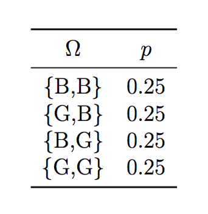

By telling us that one sibling is a girl, we elminate the possibility of the event $\{B,B\}$ occuring. Thus, the probability that the other sibling is a girl is associated with the event $\{G,G\}$.

$$\begin{eqnarray}
P(\{G,G\}| \{B,B\}^c) & = & \frac{P(\{G,G\} \cap \{B,B\}^c)}{P(\{B,B\}^c)} \nonumber \\
& = & \frac{0.25}{0.75} \nonumber \\
& = & \frac{1}{3} \nonumber
\end{eqnarray}$$

#### (b) Later in the conversation, it becomes apparent that she was discussing the older sibling.

Does this change your probability that the other sibling is a girl?

Yes. Using the sample space $\Omega$ described above, we have a new conditional probability

$$\begin{eqnarray}
P(\{G,G\}| \{B,B\}^c \cap \{G,B\}^c ) & = & \frac{P(\{G,G\} \cap \{\{B,B\}^c \cap \{G,B\}^c \})}{P(\{B,B\}^c \cap \{G,B\}^c)} \nonumber \\
& = & \frac{0.25}{0.5} \nonumber \\
& = & \frac{1}{2} \nonumber
\end{eqnarray}$$

### HW2 Problem 13

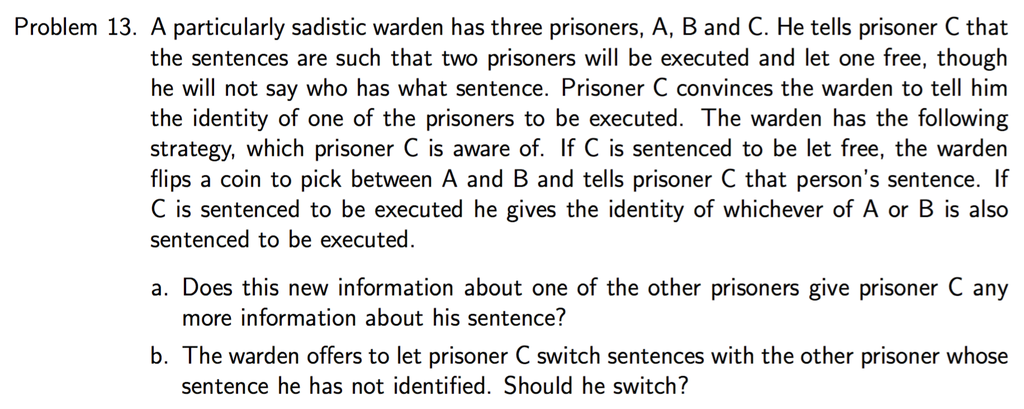

#### (a) Does this new information about one of the other prisoners give prisoner C any more information about his sentence?

- P(C is let free | new information) = P(C is let free) implies that the new information give C no information about his sentence.
- Let $W$ be the even that the warden tells prisoner $C$ that $A$ is to be executed. Denote $X,Y,Z$ as the events that $A,B,C$ are to be let free, respectively.
- Assume equal probabilties for each prisoner.

We first calculate $P(W)$, then we use Bayes Rule to compute $P(Z|W)$.

$$\begin{eqnarray}
P(W) &=& P(W|X)P(X) + P(W|Y)P(Y) + P(W|Z)P(Z) \nonumber \\
&=& 0 \times \frac{1}{3} + 1 \times \frac{1}{3} + \frac{1}{2}\times \frac{1}{3} \nonumber \\
&=& \frac{1}{2}
\end{eqnarray}$$
$$\begin{eqnarray}
P(Z|W) & = & \frac{P(Z \cap W)}{P(W)} \nonumber \\
& = & \frac{P(W|Z)P(Z)}{1/2} \nonumber \\
& = & \frac{(1/2)(1/3)}{1/2} \nonumber \\
& = & \frac{1}{3} \\
& = & P(Z)
\end{eqnarray}$$

The new information gives C no information about his own sentence.

#### (b) The warden offers to let prisoner C switch sentences with the other prisoner whose sentence he has not identified. Should he switch?

Yes, he should switch.

Calculate $P(Y|W)$. If $P(Y|W) > P(Z|W)$, prisoner $C$ should switch.

$$\begin{eqnarray}
P(Y|W) & = & \frac{P(Y \cap W)}{P(W)} \nonumber \\
& = & \frac{P(W|Y)P(Y)}{1/2} \nonumber \\
& = & \frac{(1)(1/3)}{1/2} \nonumber \\
& = & \frac{2}{3} \nonumber
\end{eqnarray}$$

Thus, prisoner C should switch.

```r
nsim <- 1000; set.seed(10312)
ps <- LETTERS[1:3]
## first two columns are prisoners set to be executed
exec <- t(replicate(nsim, sample(ps)))
## who is the other prisoner whose sentence he has not identified
tell <- ifelse(exec[,3] == "C", sample(ps[1:2], size=1), exec[,3])
## never switch
(psurv_no_switch <- mean(exec[,3]=="C"))
```

```
## [1] 0.337
```

```r
## always switch
(psurv_switch <- mean(exec[,3] == tell))
```

```
## [1] 0.663
```

### HW2 Problem 14

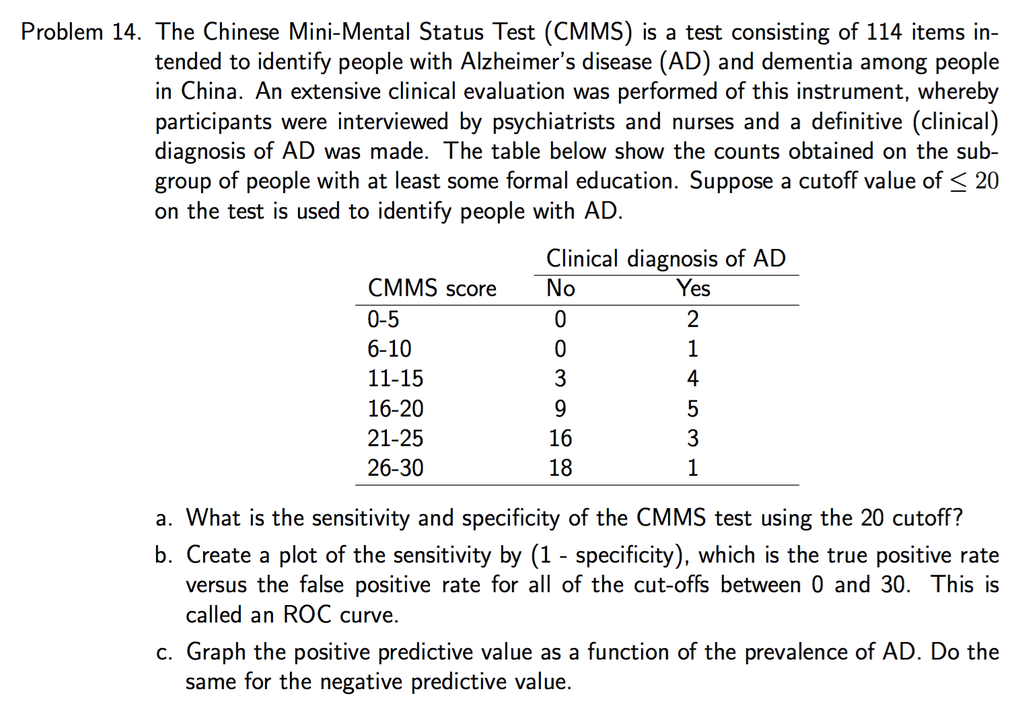

#### (a) What is the sensitivity and specificity of the CMMS test using the 20 cutoff?

- Let $+$ and $-$ be the events that the CMMS test is positive or negative, respectively.
- Further let $D$ and $D^c$ as the event that an individual has the disease, respectively.
- Then for a cutoff of $\leq 20$ we have
  - Sensitivity = $P(+|D) = \frac{12}{16} = 0.75$.
  - Specificity = $P(-|D^c) = \frac{34}{46} = 0.74$.

#### (b) Create a plot of the sensitivity by (1 - specificity), which is the true positive rate versus the false positive rate for all of the cut-offs between 0 and 30. This is called an ROC curve.

See Figure below.

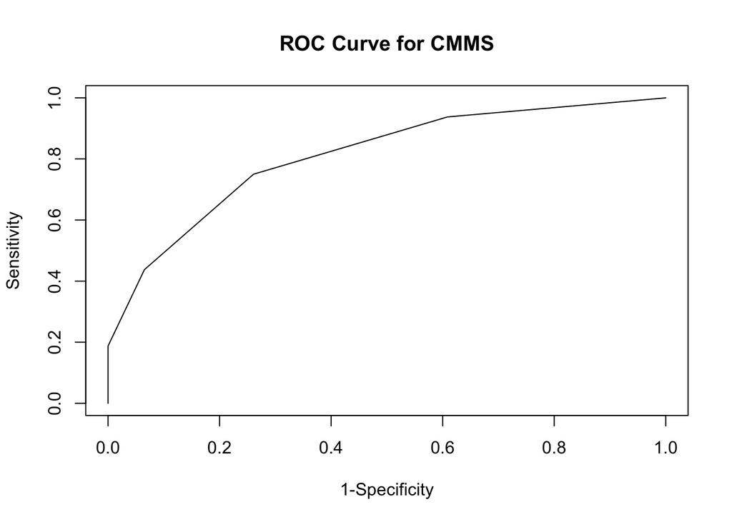

```r
## add in a 0 cut-off not in the data table
dat <- data.frame("score" = seq(0,30,by=5),
                  "No" = c(0,0,0,3,9,16,18),
                  "Yes" = c(0,2,1,4,5,3,1))
nLevels <- nrow(dat)

sens <- spec <- rep(NA, nLevels)
for(i in 1:nLevels){
    test_pos <- dat[1:i,-1,drop=FALSE]
    test_neg <- dat[-c(1:i),-1,drop=FALSE]

    sens[i]  <- sum(test_pos$Yes)/sum(dat$Yes)
    spec[i]  <- sum(test_neg$No)/sum(dat$No)
}

plot(1-spec, sens, ylab="Sensitivity", xlim=c(0,1),ylim=c(0,1),
     xlab="1-Specificity", main="ROC Curve for CMMS", type='l')
```

#### (c) Graph the positive predictive value as a function of the prevalence of AD.

Do the same for the negative predictive value.

Using the cutoff of $20$ sated in the problem, and the formula

$$PPV = P(D|+) = \frac{P(+|D)P(D)}{P(+|D)P(D) + P(+|D^c)P(D^c)}$$

we create the graph below.

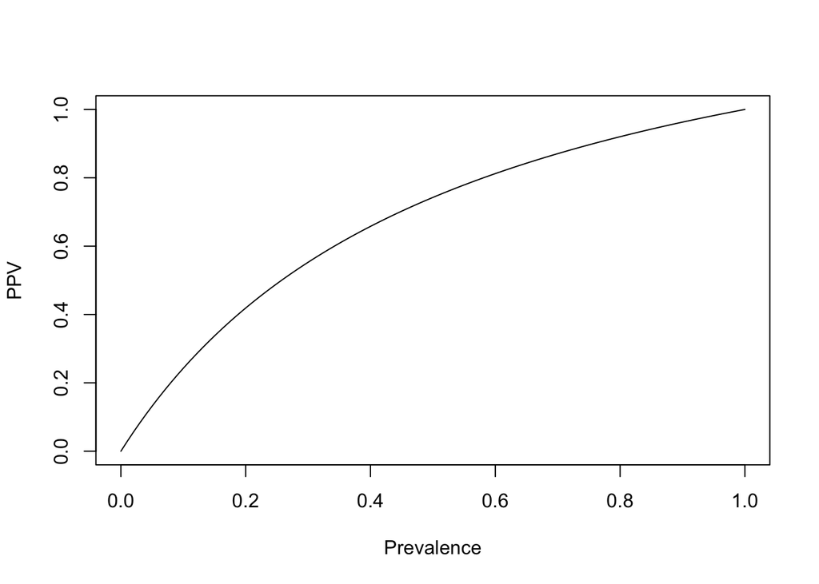

```r
p    <- seq(0,1,len=100)
sens <- 0.75; spec <- 0.74
PPV  <- sens*p/(sens*p + (1-spec)*(1-p))

plot(p, PPV, xlab="Prevalence", ylab="PPV", main="", type='l')
```